# 狂言基礎講座

1/17の狂言の会の前に

大野隼太郎

December 30, 2025

# 1 この資料について

今回は狂言の公演会にご参加を決めていただき誠にありがとうございます。みなさんにご連絡した時点では5~6人集まれば御の字かと思っていましたが、最終的に11名の方にご参加いただけることになり一狂言愛好家として大変嬉しく思います。折角安くはない金額を払って観ていただくのですから、当日最大限に楽しんでいただける様、解説資料を作成しましたので当日までに目を通していただけると嬉しいです。

# 2 能と狂言の違い

能・狂言は共に14世紀（室町時代）に成立し、現代では両者を合わせ能楽というジャンルで括られています。どちらも同じ能舞台を使用するので混同されがちですが、能と狂言には明確に違いがあります。

## 2.1 能

能は亡霊や神仏、精霊といった現実を超越した存在が主人公となることが多いのが特徴です。シテ（写真/中央に立つ人物）、ワキ（写真/右側に座っている紫色の人物）、地謡（写真/舞台右手に座るコーラス隊）、囃子（写真/舞台後方に陣取る楽器隊）など様々な役割の能楽師が登場します。セリフは超難解で、上演時間も1〜2時間に亘るので、毎回序盤〜中盤は睡気との闘い、後半になるとお尻が痛くて堪りません。

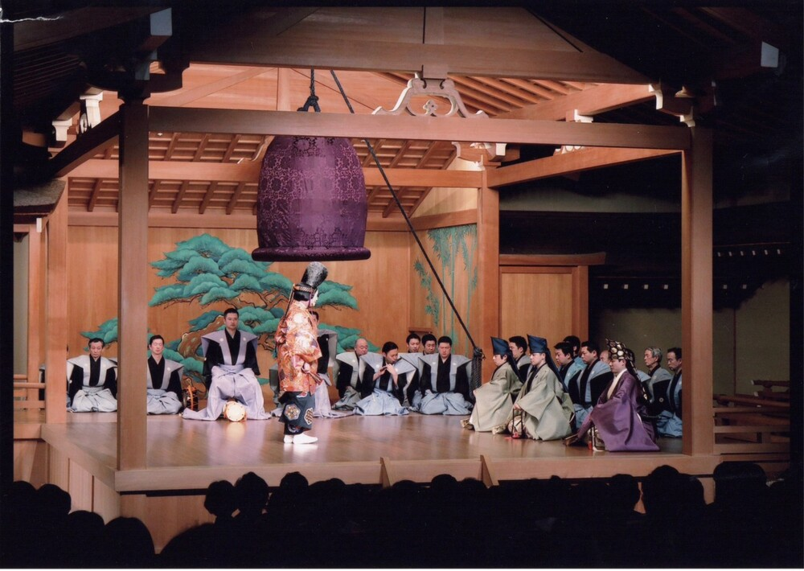

写真1. 能/道成寺

## 2.2 狂言

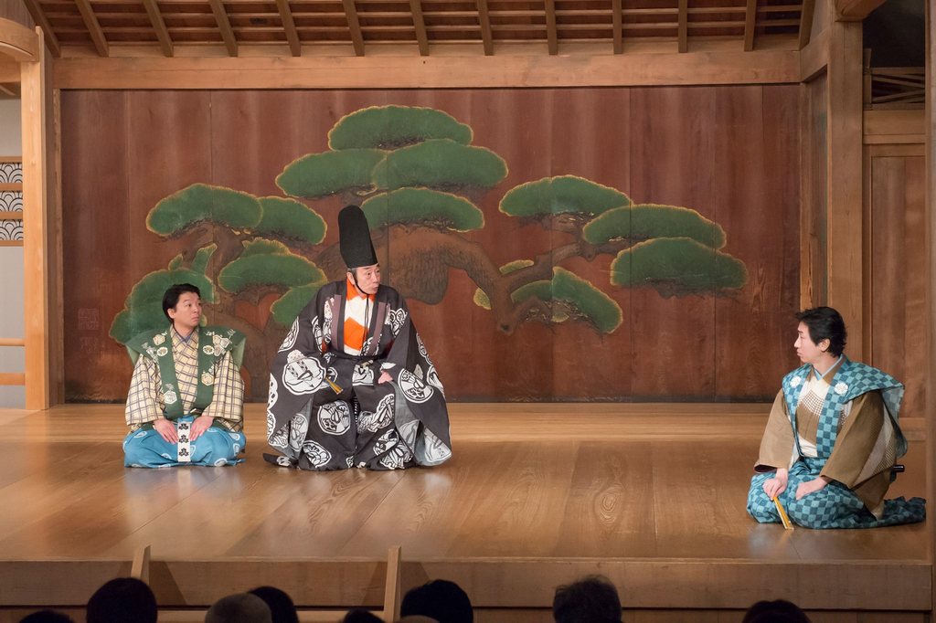

写真2. 狂言/萩大名

> 世阿弥は悪霊にさえ、幽玄をたたえた演技を求め、また彼があまり高く評価していなかった狂言師についても、もしその滑稽な演技が卑俗に落ちることなしに観客を魅了するのなら、そこには幽玄が存在すると不本意ながら認めたとも言える。狂言に俗悪な所があまり混じっていないのは、世阿弥がそれらを嫌っていたことで説明がつくだろう。西洋の中世の喜劇と比較してもそれは歴然としているが、もっとも彼が生きた時代には狂言のかなりの部分ば卑猥な内容や茶番劇が混然一体となった即興劇であったかも知れない。もちろん、今日ではセリフは明晰な発声のために細部にまで神経が配られているし、文学的にも相当整えられ、日本の舞台芸術の中でもユニークなものとなっている。狂言においても謡いや舞いはあるが、強調されることは多くない。狂言とは本質的に会話劇であり、登場する者たちの対立に導かれるのであって、能のように一人のシテが放つオーラの上に成り立つものではないのである。狂言での役柄はCommedia dell’arte（16世紀中頃から18世紀の初めにイタリアで栄えた即興喜劇）とは違って類型的なものばかりで、役柄の範囲もこの時代の日本を取り巻く状況によって極めて限られていた。当時の日本とは鎖国の時代であり、15世紀から16世紀にかけて日本を訪れたわずかな中国人や朝鮮人が笑劇の中に登場することはあり得なかった。それは、ヨーロッパの笑劇のように、好色なフランス人、打ち解けないイギリス人、粗野なアメリカ人といった具合に外国人を笑いの種にすることが狂言においてはなかったということでもある。外国人が出ないことは鎖国だけが理由ではなかった。狂言のユーモアとは同じ立場の家来や二人の殿様、あるいは異なる国から来た二人の外国人といった同等の人物を扱うのではなく、股様と家来の間柄のように、基本的には上下関係に基づいたものであるからだ。また。それだけではなく、田舎者がおかしく描かれているのは方言や時代遅れとなった言葉を使うことではなく、気の利いた詩を詠めない田舎大名といった具合に身の程知らずな振る舞いに及ぶことによってである。

> もっとも頻繁に使われる喜劇的設定は、愚かな主人が如才のない家来騙されるという変わることのない構図である。ある学者に言わせると、家来が主人を出し抜くという設定には、民衆の怒りの声を表したものというし、また、そういった学説を裏打ちするような狂言もいくつか存在する。しかし、常識的に言って、聡明な主人が恵まれない家来を凌ぐのでは喜劇と言えないだろう。そして、劇中に、もし将軍や宮廷の権力を脅かすような風刺があれば、能、狂言を後援していた彼等は決してそれを容認しなかっただろう。

# 3 演目紹介

江戸時代には「能奉行」という能の公演を取り仕切る役職がありました。その奉行へ各流儀の家元が、上演可能な演目の一覧を提出し、それを元に能奉行は演目を決めていました。その一覧を名寄なよせと呼んでおり、現在の名寄せ（写真3）は江戸最後の名寄せを元にまとめられたものです。演目のジャンルによって、脇狂言/大名狂言/聟女狂言などと括られており、約150曲が存在します。今回は集狂言から酢薑、出家座頭狂言から惣八、聟女狂言から業平餅がピックアップされています。

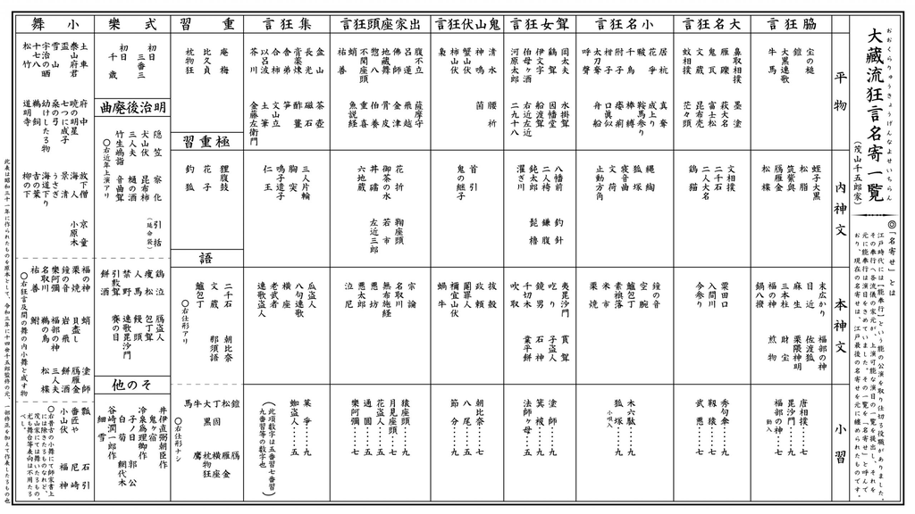

写真3. 大蔵流狂言名寄一覧（画像をタップすると拡大できます）

## 3.1 酢薑すはじかみ

摂津の国の薑はじかみ売りと和泉の国の酢売りが、都へ商売に行く途中に出会い、売り物の司を争い合います。まずは互いの由緒を語り合い、次に二人は秀句を言い合って勝負をつけることにしますが…。秀句とは酒落のことです。薑売りはが「辛い」ことから「カラ」の音を、酢売りは「ス」の音を強調して言ります。薑とは[現在では生姜を指す](https://delishkitchen.tv/articles/1060)ことが多いが、昔は山椒のことを指しました。商売人らしく、それぞれの売物の言葉を織り混ぜて言い争います。

## 3.2 惣八そうはち

ある家の主人が僧侶と料理人を召し抱えるため高札を揚げます。そこへ最近まで料理人をしていた僧侶と、最近まで僧侶であった惣八と名のる料理人がやって来て雇われます。 主人は僧に法華経の読経を、惣八には鯛と鯉を料理するように言いつけます。二人はやり慣れないことに戸惑い、相談して元の仕事と取り換えます。料理人姿の惣八が経を読み、元料理人が僧の姿で料理をして…。出家の料理人と元料理人の出家が、同じ主人に抱えられたことから起こるドタバタ喜劇です。また鯛と鯉を乗せたまな板を出して元料理人の出家が料理をする手付きも見所です。

## 3.3 業平餅なりひらもち

[在原業平ありわらのなりひら](https://ja.wikipedia.org/wiki/在原業平)が供の者たちを従えて、和歌の神様として名高い、和歌山の[玉津島神社](https://tamatsushimajinja.jp)へ参詣に出かけます。途中で空腹を感じた業平は道端の茶屋にて休息を取り、名物の餅を所望します。代金は前払いと言われますが、業平はお金のような下賤なものは持っておりません。美味しそうな餅を目の前に、空腹に耐えかねた業平は「餅尽くし」の小舞を謡い舞い始めます。見かねた茶屋の亭主が出した交換条件とは…。和歌の名人として名高い「六歌仙」の一人、在原業平が主人公の狂言です。通常狂言には、歴史や物語でお馴染みの著名な人物が主人公になる作品はほとんどありませんが、この作品は例外です。和歌の名手・美男子として名高い業平が狂言ではどのように描かれているのかお楽しみください。

# 4 狂言の装束

公演当日は多種多様な装束にもぜひ注目してもらえたらと思います。ここでは、狂言装束における特徴を2点お伝えします。

## 4.1 肩衣

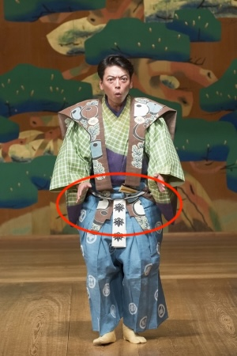

写真4. 狂言における最も代表的な衣装/茂山宗彦

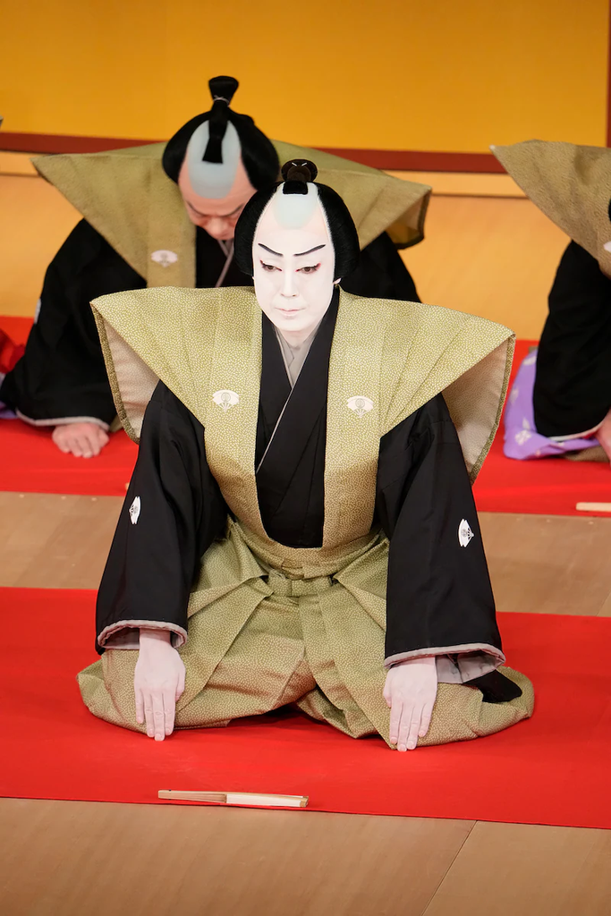

写真5. 歌舞伎における裃姿/八代目尾上菊五郎

## 4.2 足袋

もう一点、狂言の衣装に特徴的なポイントがあります。公演中、役者の足元の足袋たびにも注目してみてください。足袋といえば白色が一般的ですが、狂言の足袋は黄色なのです。これは、能や狂言が芸能として確立した室町時代に、能には白に染められた鹿の革足袋が用いられていたのに対し、庶民の芸能であった狂言には白足袋が許されておらず、色の染められていない革足袋が用いられていた名残であると言われております。尤も本当の由縁は定かではありませんが…

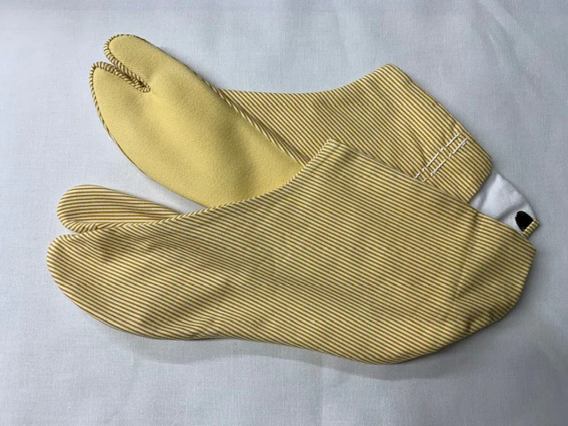

写真6. 狂言足袋

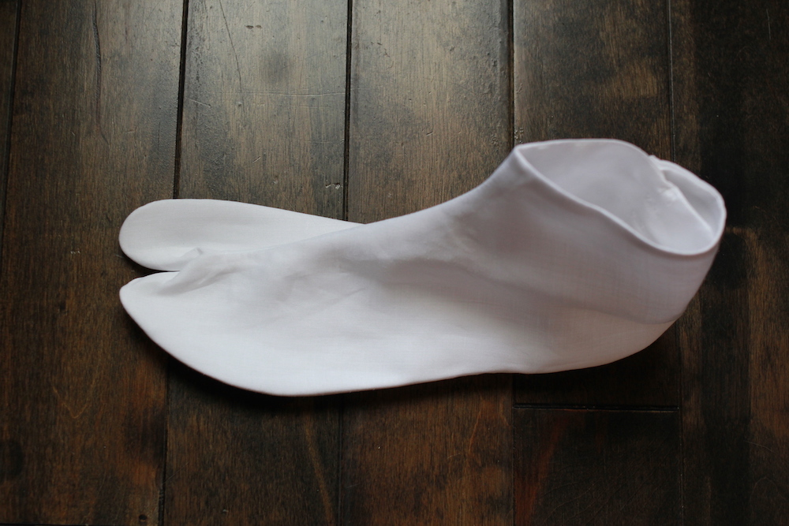

写真7. 白足袋

# 5 狂言の家

## 5.1 流派

現代の狂言には和泉いずみ流と大蔵おおくら流の2流派が存在します。それぞれの流派の中に家単位の派閥があり、狂言の公演は基本的に家単位で行われます。みなさんもご存知であろう野村萬斎や和泉元彌は和泉流狂言師です。大雑把にまとめると、その昔、和泉流は京都御所勤め、大蔵流は幕府勤めでした。明治以降、遷都と共に和泉流は東京を拠点として活動するようになり、幕府の後援を失った大蔵流は東京や関西に分散していきました。大蔵流狂言師の家は現在5家ありますが、その中で最も勢いのある家が京都を拠点としている茂山千五郎家なのです。

- 和泉流
  - 野村万作家（東京）
  - 野村万蔵家（東京）
  - 野村又三郎家（名古屋）
  - 三宅家（東京）
- 大蔵流
  - 茂山千五郎家（京都）
  - 茂山忠三郎家（京都）
  - 山本家（東京）
  - 大蔵家（京都）
  - 善竹家（京都）
- 鷺さぎ流：明治期に断絶

## 5.2 茂山千五郎家

今回は大蔵流の茂山千五郎家の狂言を観ていただくので、ここで少し紹介させてください。茂山家は京都を拠点に活動しており、2025年現在は20名の役者（茂山姓12名＋弟子8名）が所属しています。関西人らしく、みなさんおもろいことが大好きで、芸風も大らかでこちらの笑いを引き出す技術に長けていると感じます。一方で、狂言は中世のコントといえど、格式のある伝統芸能ですから、おもろければ何でもいいわけではなく、ビシッとするときはビシッとする、そんなメリハリの利いたスタイルが貫かれています。

- [茂山千五郎家ホームページ](https://kyotokyogen.com/about/sengoroke/)
- [茂山千五郎家公演スケジュール](https://kyotokyogen.com/schedule/)

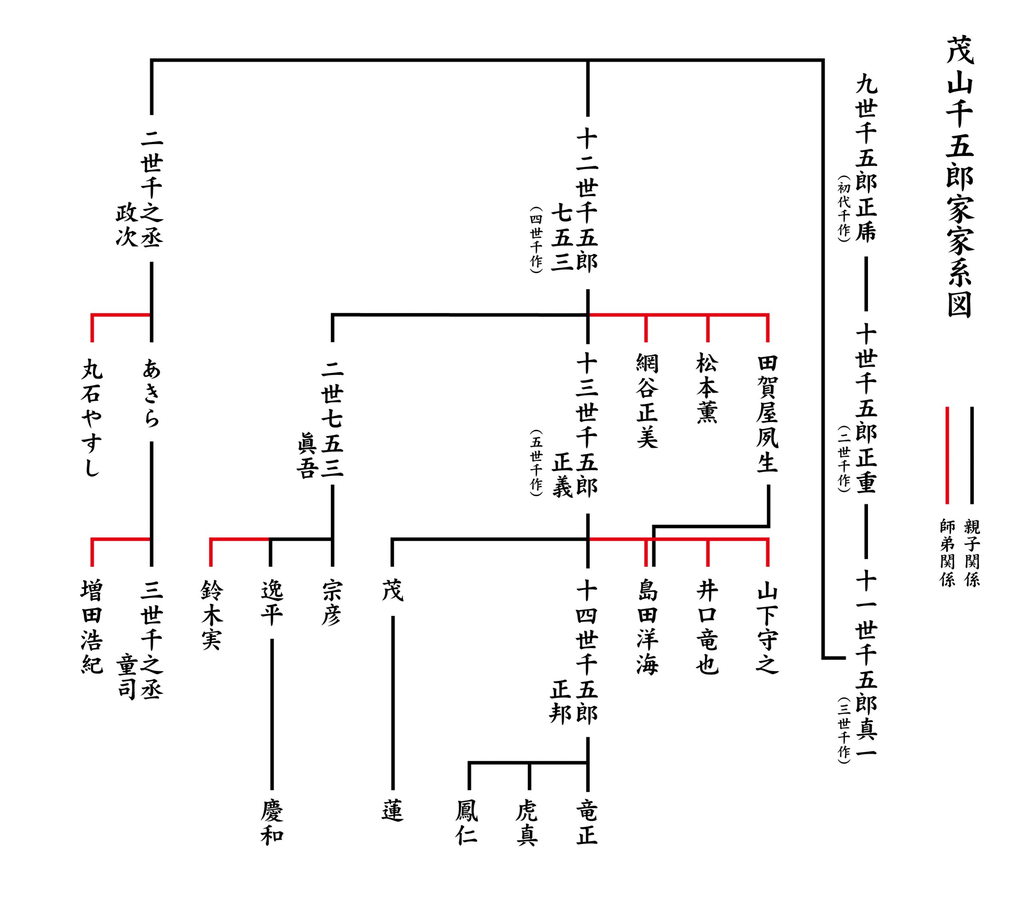

写真8. 茂山千五郎家系図